# Лабораторная работа №4

Операционные системы

Ежова А. М.

Российский университет дружбы народов, Москва, Россия

Факультет физико-математических и естественных наук

02 марта 2023

# Информация

## Докладчик

- Ежова Алиса Михайловна
- студентка НБИбд-01-22
- Российский университет дружбы народов
- https://github.com/AlisaEzhova

[figure not shown]

# Вводная часть

## Актуальность

Данная лабораторная работа актуальна для студентов, кто хочет приобрести практические навыки взаимодействия пользователся с системой посредством командной строки.

# Цели и задачи

- Приобретение практических навыков взаимодействия пользователя с системой посредством командной строки.

## Материалы и методы

- Процессор `pandoc` для входного формата Markdown
- Результирующие форматы
  - `pdf`
  - `html`
- Автоматизация процесса создания: `Makefile`

# Создание презентации

## Процессор `pandoc`

- Pandoc: преобразователь текстовых файлов
- Сайт: https://pandoc.org/
- Репозиторий: https://github.com/jgm/pandoc

## Формат `pdf`

- Использование LaTeX
- Пакет для презентации: beamer
- Тема оформления: `metropolis`

## Код для формата `pdf`

```yaml
slide_level: 2
aspectratio: 169
section-titles: true
theme: metropolis
```

## Формат `html`

- Используется фреймворк [reveal.js](https://revealjs.com/)
- Используется [тема](https://revealjs.com/themes/) `beige`

## Код для формата `html`

- Тема задаётся в файле `Makefile`

```
REVEALJS_THEME = beige
```

## Содержание исследования

1. Определила полное имя моего домашнего каталога:

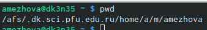

Домашний каталог

2. Перешла в каталог tmp:

2.2) Вывела на экран содержимое каталога tmp с помощью команды ls:

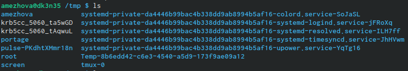

Содержимое каталога tmp

Команда ls с опцией -a. Отображает имена скрытых файлов:

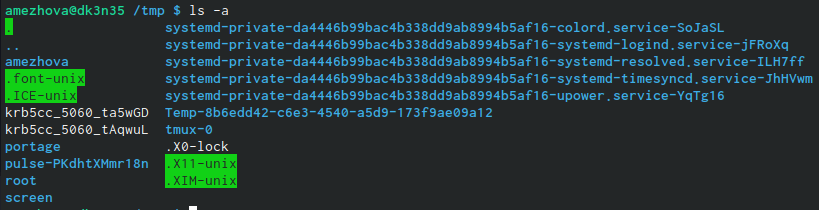

Команда ls с опцией -a

Команда ls с опцией -F. Получаем информацию о типах файлов:

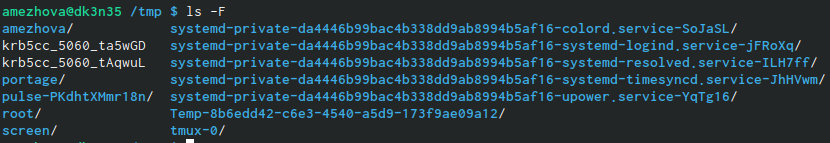

Команда ls с опцией -F

Команда ls с опцией -l и -alF. Выводит на экран подробную информацию о файлах и каталогах:

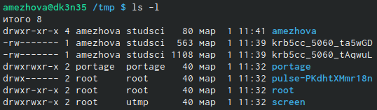

Команда ls с опцией -l

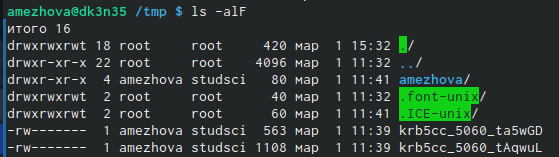

Команда ls с опцией -alF

2.3) Определила есть ли в каталоге /var/spool подкаталог с именем cron:

Каталоге /var/spool

[figure not shown]

Каталоге /var/spool

2.4) Перешла в домашний каталог и вывела его содержимое:

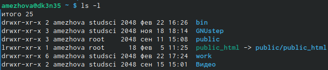

Домашний каталог

3. В домашнем каталоге создала новый каталог с именем newdir:

Новый каталог

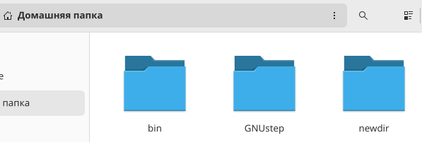

Новый каталог

3.2) В каталоге newdir создала новый каталог с именем morefun:

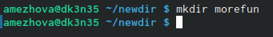

Новый каталог

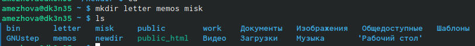

Новые каталоги

Затем удалила эти каталоги одной командой:

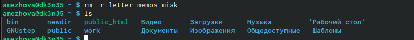

Удаление

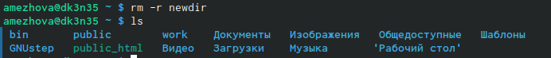

Удаление

4. С помощью команды man определила, какую опцию команды ls нужно использо- вать для просмотра содержимое не только указанного каталога, но и подкаталогов, входящих в него:

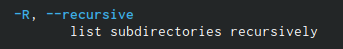

Просмотр содержимого

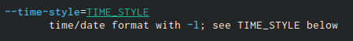

6. Используйте команду man для просмотра описания следующих команд: cd, pwd, mkdir, rmdir, rm:

man cd:

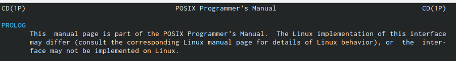

man cd

man pwd:

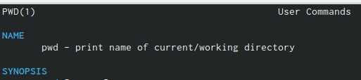

man pwd

man mkdir:

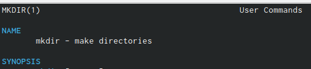

man mkdir

man rmdir:

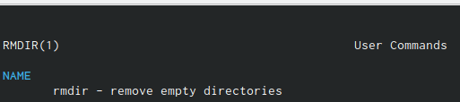

man rmdir

man rm:

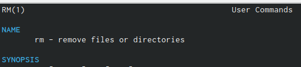

man rm

7. Используя информацию, полученную при помощи команды history, выполнила мо- дификацию и исполнение команды из буфера команд:

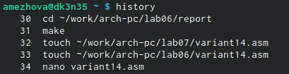

History

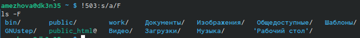

Модификация команды

## Итоговый слайд

В ходе выполнения лабораторной работы №4, я приобрела практические навыки взаимодействия пользователя с системой посредством командной строки.